# Lista 1 de Administração Financeira II

### Questão 14

### Com base nas informações apresentadas no quadro, abaixo, se tivesse que investir em apenas 1 ativo, qual deles escolheria?

```r
df = data.frame(Ativo.A = c(0.1, 0.08),
                Ativo.B = c(0.17, 0.13),
                Ativo.C = c(0.13, 0.09),
                Ativo.D = c(0.22, 0.17),
                Ativo.E = c(0.19, 0.15),
                row.names = c("E[R]","SD"))
df
```

```
##      Ativo.A Ativo.B Ativo.C Ativo.D Ativo.E
## E[R]    0.10    0.17    0.13    0.22    0.19
## SD      0.08    0.13    0.09    0.17    0.15
```

Embora o ativo D tenha retorno de 22% o risco é o mais alto entre os ativos, de 17%. Logo escolheria o ativo B que apresenta retorno de 17% e risco de 13%

### Questão 15

### Com base nas informações apresentadas no quadro, abaixo, se tivesse que investir em 2 ativos, qual par deles escolheria admitindo 50% de investimento em cada?

```r
print(df)
```

```
##      Ativo.A Ativo.B Ativo.C Ativo.D Ativo.E
## E[R]    0.10    0.17    0.13    0.22    0.19
## SD      0.08    0.13    0.09    0.17    0.15
```

```r
cat('
A e E,  0.49
B e C,  0.30
B e D,  0.05 Escolheria essa aqui pq a correlação está próxima de 0, além dos ativos B e D apresentarem retorno esperado e desvio-padrão de 0.17 e 0.13 para B, 0.22 e 0.17 para D.
D e E, -0.55
')
```

```
##
## A e E,  0.49
## B e C,  0.30
## B e D,  0.05 Escolheria essa aqui pq a correlação está próxima de 0, além dos ativos B e D apresentarem retorno esperado e desvio-padrão de 0.17 e 0.13 para B, 0.22 e 0.17 para D.
## D e E, -0.55
```

### Questão 16

### Com base nas informações apresentadas no quadro, abaixo, qual deve ser a quantidade de dinheiro a ser investida em A e B, admitindo-se que o investidor tenha R$ 10.000 disponível para investimento?

```r
df = data.frame(Ativo.A = c(0.1, 0.08, 0),
                Ativo.B = c(0.17, 0.13, 0),
                row.names = c("E[R]", "SD", "Corr(A,B)"))
df
```

```
##           Ativo.A Ativo.B
## E[R]         0.10    0.17
## SD           0.08    0.13
## Corr(A,B)    0.00    0.00
```

```r
wA = round(df[2,2]^2/(df[2,1]^2+df[2,2]^2),4)
wB = 1-wA

cat("O investidor deveria investir R$", wA*10000, "em A e R$", wB*10000, "em B.")
```

```
## O investidor deveria investir R$ 7253 em A e R$ 2747 em B.
```

### Questão 17

### Considere dois ativos, abaixo:

```r
df = data.frame(Ativo.A = c(0.14, 0.11, 0.52),
                Ativo.B = c(0.27, 0.18, 0.52),
                row.names = c("E[R]", "SD", "Corr(A,B)"))
df
```

```
##           Ativo.A Ativo.B
## E[R]         0.14    0.27
## SD           0.11    0.18
## Corr(A,B)    0.52    0.52
```

Qual deve ser a quantidade investida (%) em A e B que retorne uma carteira de menor risco possível?

```r
wA = round((df[2,2]^2-df[3,1]*df[2,1]*df[2,2])/
             ((df[2,1]^2 + df[2,2]^2)-(2*df[3,1]*df[2,1]*df[2,2])),4)
wB = 1-wA

cat("O investidor deverá investir R$", wA*10000, "em A e R$", wB*10000, "em B.")
```

```
## O investidor deverá investir R$ 9245 em A e R$ 755 em B.
```

### Questão 18

### Considerando a fronteira eficiente, abaixo (imagem na lista), você recomendaria um investidor alocar todo seu dinheiro em títulos de renda fixa (Bond)? Justifique

### Resposta:

Não seria recomendado investir 100% do capital em renda fixa (Bond), pois o risco é mais alto do que investir 75% em Bonds e 25% em Stocks, que apresenta risco menor e retorno acima do que depositar 100% em Bonds. A recomendação seria distribuir em 75% para Bonds e 25% para Stocks, onde licaliza-se a zona de menor risco e maior retorno.

### Questão 19

### Considerem-se as seguintes ações:

```r
print(data.frame(Beta = c(1.4, 0.7),
                 Retorno = c(0.25, 0.14),
                 row.names = c("TaxOver", "InnerCity")))
```

```
##           Beta Retorno
## TaxOver    1.4    0.25
## InnerCity  0.7    0.14
```

Suponha que o CAPM seja válido. De acordo com o CAPM qual é o retorno esperado do mercado? Qual é o valor da taxa livre de risco?

```r
beta.TO = 1.4; betaIC = 0.7; ret.TO = 0.25; ret.IC = 0.14

# 0.25 = rf + 1.4*(rm - rf)
# 0.25 = rf - 1.4*rf + 1.4*rm
# 0.25 = -0.4*rf + 1.4*rm

# 0.14 = rf + 0.7*(rm - rf)
# 0.14 = rf - 0.7*rf + 0.7*rm
# 0.14 = 0.3*rf + 0.7*rm

# 0.25 = -0.4*rf + 1.4*rm
# (0.14 = 0.3*rf + 0.7*rm) * -2
# -0.28 = -0.6*rf - 1.4*rm
#_____________________________
# -0.03 = -rf + 0*rm
rf = 0.03 # Taxa livre de risco

# 0.25 = -0.4*0.03 + 1.4*rm
rm = (0.25 + 0.4*0.03)/1.4
# rm = 0.1871429 # Retorno esperado do mercado

cat("Valor da taxa livre de risco: ", rf, "\n\n",
    "Valor da taxa de mercado: ", rm, sep = "")
```

```
## Valor da taxa livre de risco: 0.03
##
## Valor da taxa de mercado: 0.1871429
```

### Questão 20)

### Suponha que seja observada a seguinte situação:

```r
df = data.frame(Prob = c(0.25, 0.5, 0.25),
                Ret.A = c(-0.1, 0.1, 0.2),
                Ret.B = c(-0.3, 0.05, 0.4),
                row.names = c("Recessão", "Estabilidade", "Expansão"))

df
```

```
##              Prob Ret.A Ret.B
## Recessão     0.25  -0.1 -0.30
## Estabilidade 0.50   0.1  0.05
## Expansão     0.25   0.2  0.40
```

1. Calcule o retorno esperado de cada ação
2. Supondo que o CAPM seja válido e o beta da ação A seja 0,25 maior do que o beta da ação B, qual o valor do prêmio pelo risco?

```r
# Alternativa a)
ret.esp.A = sum(df[,1] * df[,2])
ret.esp.B = sum(df[,1] * df[,3])

cat("Retorno esperado de A: ", ret.esp.A, "\n\n",
    "Retorno esperado de B: ", ret.esp.B, sep = "")
```

[output not shown]

```
## Retorno esperado de A: 0.075
##
## Retorno esperado de B: 0.05
```

### Questão 21)

### Com base nas informações abaixo produza a Linha de Mercado de Títulos (LMT)

1. No caso em que o prêmio pelo risco de mercado é igual a 5% e a taxa livre de risco é igual a 7%
2. Suponha que um ativo tenha beta de -1 e retorno esperado igual a 4%. Coloque-o no gráfico desenhado no item (a). O ativo está corretamente avaliado? Caso contrário o que ocorrerá nesse mercado?
3. Suponha que um ativo tem beta igual a 3 e retorno esperado de 20%. Coloque-o no gráfico desenhado no item (a). O ativo está corretamente avaliado? Se não estiver explique o que ocorrerá nesse mercado.

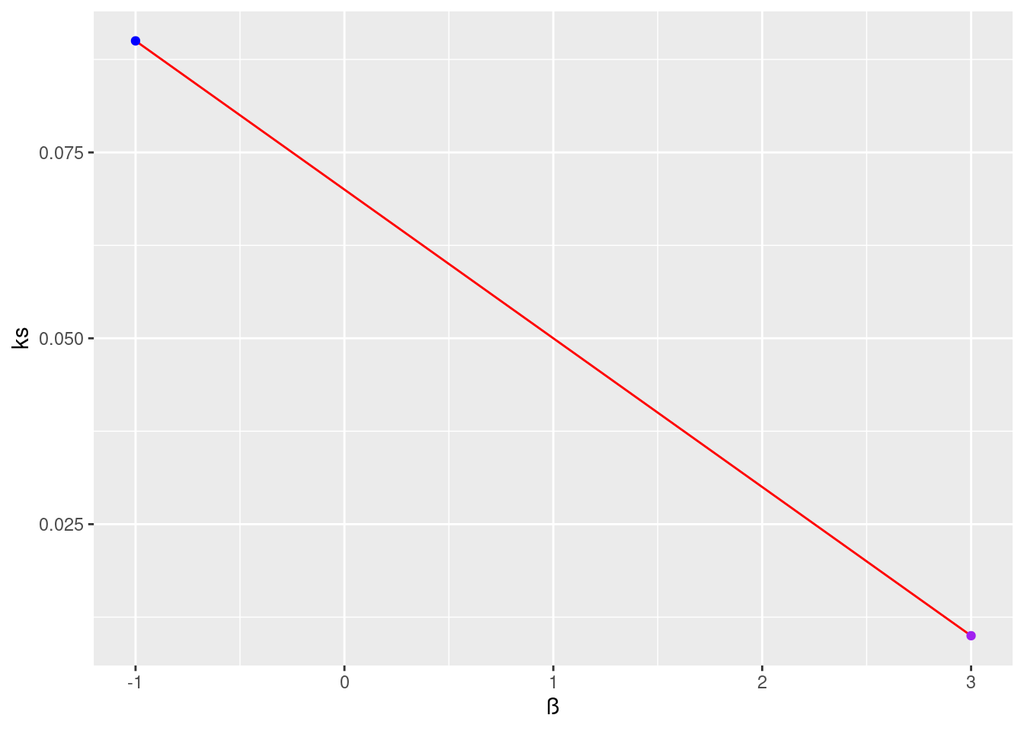

```r
# Alternativas a, b e c)
ß = seq(-1, 3, 0.05)
ks = 0.07 + (0.05 - 0.07)*ß

ggplot()+
  geom_line(aes(x = ß, y = ks), col = "red") +
  geom_point(aes(x = ß[1], y = 0.07 + (0.05 - 0.07)*ß[1]), col = "blue") +
  geom_point(aes(x = 3, y = 0.07 + (0.05 - 0.07)*3), col = "purple")
```

```r
ks1 = 0.07 + (0.05 - 0.07)*ß[1]
ks2 = 0.07 + (0.05 - 0.07)*3

paste0("Valor da taxa requerida de retorno para ß = -1 é de: ", ks1*100, "%. ",
       "Logo o título está super-avaliado, pois a taxa de retorno esperado é de 4%, inferior ao requerido para o título. ",
       "Dessa forma, o mercado poderá ser deficitário ou apresentar retornos abaixo do esperado.")
```

```
## [1] "Valor da taxa requerida de retorno para ß = -1 é de: 9%. Logo o título está super-avaliado, pois a taxa de retorno esperado é de 4%, inferior ao requerido para o título. Dessa forma, o mercado poderá ser deficitário ou apresentar retornos abaixo do esperado."
```

```r
paste0("Valor da taxa requerida de retorno para ß = 3 é de: ", ks2*100, "%. ",
       "Logo o título está sub-avaliado, pois a taxa de retorno esperado é de 20%, superior ao requerido para o título. ",
       "Dessa forma, o mercado poderá ser superavitário ou apresentar retornos acima do esperado.")
```

```
## [1] "Valor da taxa requerida de retorno para ß = 3 é de: 1%. Logo o título está sub-avaliado, pois a taxa de retorno esperado é de 20%, superior ao requerido para o título. Dessa forma, o mercado poderá ser superavitário ou apresentar retornos acima do esperado."
```

### Questão 22)

### Suponha que a taxa livre de risco seja de 6,3% e que a carteira de mercado tenha retorno esperado de 14,8%. A carteira de mercado também possui variância de 0,0121. A carteira Z tem um coeficiente de correlação com o mercado igual a 0,45 e sua variância é 0,0169. De acordo com o CAPM, qual é a taxa esperada de retorno da Carteira Z?

```r
tlr = 0.063; ret.esp.merc = 0.148; var.merc = 0.0121
corrZM = 0.45; var.Z = 0.0169

ks = round(tlr + (corrZM*sqrt(var.merc)*sqrt(var.Z)/var.merc) * (ret.esp.merc - tlr),4)

cat("Taxa esperada de retorno igual a", ks)
```

```
## Taxa esperada de retorno igual a 0.1082
```

### Questão 23)

### Suponha que você tenha aplicado R$ 30.000 nas quatro ações a seguir:

```r
df = data.frame(Montante = c(5, 10, 8, 7)*1000,
                Beta = c(0.75, 1.1, 1.36, 1.88),
                row.names = paste0("Ação ",LETTERS[1:4]))
df
```

```
##        Montante Beta
## Ação A     5000 0.75
## Ação B    10000 1.10
## Ação C     8000 1.36
## Ação D     7000 1.88
```

A taxa livre de risco é igual a 4% e o retorno esperado da carteira de mercado é 15%. Com base no CAPM, qual é o retorno esperado da carteira anterior?

```r
tlr = 0.04; ret.esp.merc = 0.15

beta.cart = sum(df[,1]/sum(df[,1]) * df[,2])

ks.cart = round(tlr + beta.cart*(ret.esp.merc - tlr),4)

cat("O retorno esperado da carteira pelo CAPM é de", ks.cart)
```

```
## O retorno esperado da carteira pelo CAPM é de 0.1822
```

### Questão 24)

### Considerando uma fronteira eficiente composta por dois ativos, responda:

Alternativa a) Sim Alternativa b) Sim

### Questão 25)

### Considerando uma fronteira eficiente composta por três ativos de risco, é possível observar a superfície retorno-volatilidade exibida na próxima página. Neste sentido, responda:

1. Onde estaria o ponto que representa uma carteira de mínimo risco?
2. Que ativos dominariam esse ponto?
3. Reconheça as três fronteiras bidimensionais formadas por combinações par a par dos três ativos.